# BFA2-2008

Author

Grasland C.

## Fonds de carte

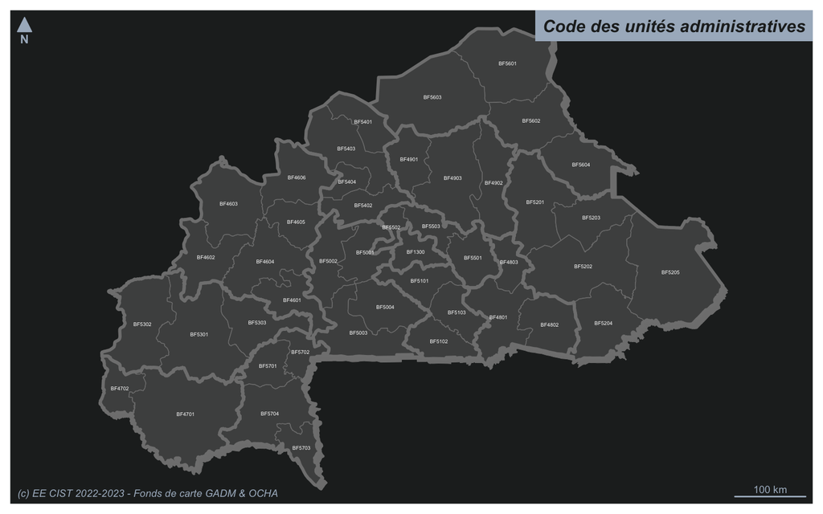

## Matrice de migration totale

On extrait la matrice de migration totale puis on calcule pour chaque paire de régions le solde et le volume des échanges.

```
# A tibble: 6 × 12
# Groups:   i [1]
  i      j     Ni    Nj      Fij   Fji  FVij  FSij      Xi     Yi      Xj     Yj
  <chr>  <chr> <chr> <chr> <dbl> <dbl> <dbl> <dbl>   <dbl>  <dbl>   <dbl>  <dbl>
1 BF1300 BF46… Kadi… Balé   1260  6530  7790  5270 -1.67e5 1.38e6 -3.42e5 1.31e6
2 BF1300 BF46… Kadi… Banwa   820  1220  2040   400 -1.67e5 1.38e6 -4.64e5 1.37e6
3 BF1300 BF46… Kadi… Kossi   610  4790  5400  4180 -1.67e5 1.38e6 -4.32e5 1.45e6
4 BF1300 BF46… Kadi… Mouh…  1760  8100  9860  6340 -1.67e5 1.38e6 -3.80e5 1.37e6
5 BF1300 BF46… Kadi… Naya…   760  5770  6530  5010 -1.67e5 1.38e6 -3.37e5 1.43e6
6 BF1300 BF46… Kadi… Sour…   850 11490 12340 10640 -1.67e5 1.38e6 -3.36e5 1.49e6
```

### Volume

On représente les volumes de flux dont la valeur est supérieure à la moyenne .

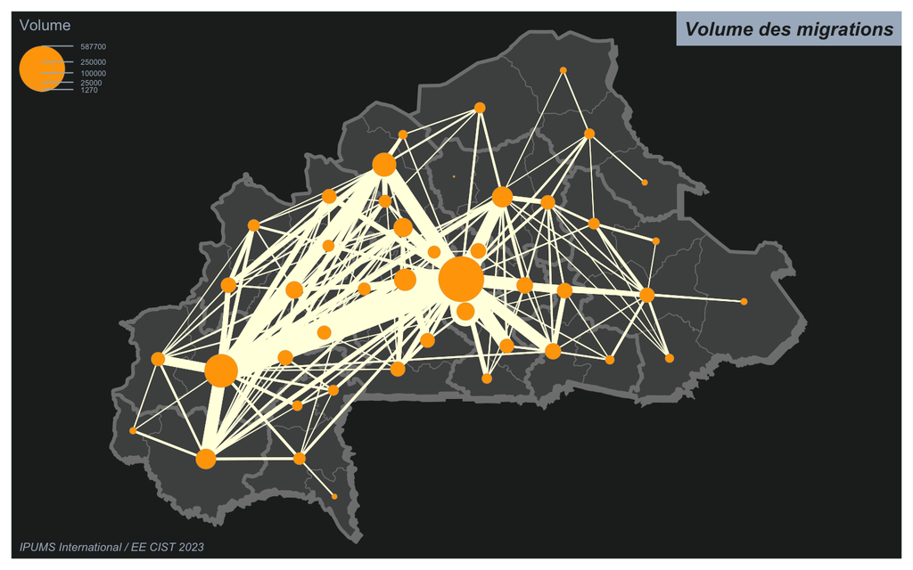

### Solde

On représente les soldes de flux dont la valeur est supérieure à la moyenne .

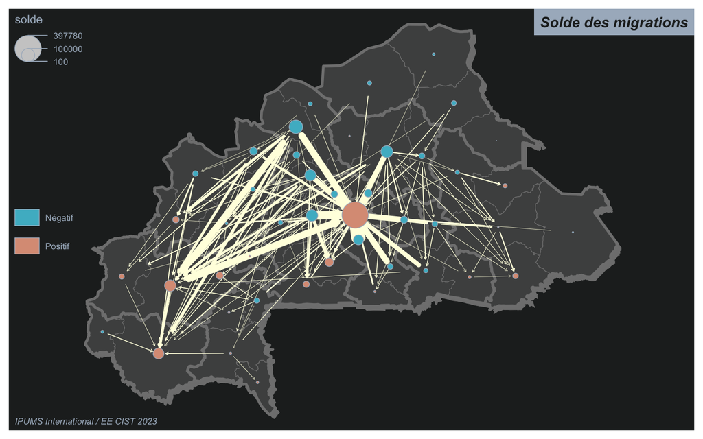

### Flux dominant

On détermine pour chaque unité spatiale son flux le plus important vers une autre unité spatiale. On considère qu’une unité est de type :

- **dominante** si son nombre si son nombre d’arrivée est supérieur à l’unité vers laquelle elle envoie son plus grand flux.
- **dominée** si son nombre d’arrivée est inférieur à l’unité vers laquelle elle envoie son plus grand flux.
- **relais** si elle est à la fois dominée et dominante.

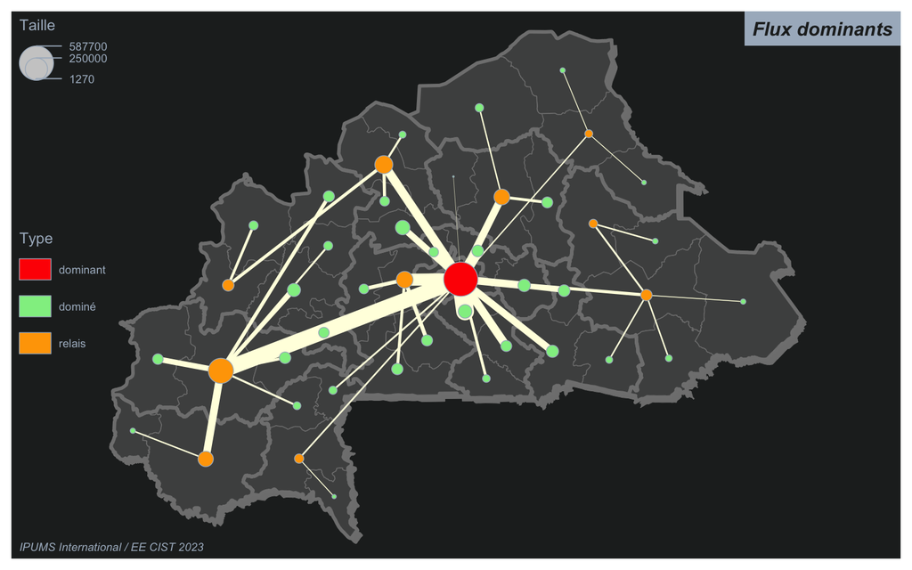